# Major Assignment 2 - Part 5

https://www.r-bloggers.com/2018/12/an-introduction-to-h2o-using-r/

```r
# this had to be upgraded
#install.packages("data.table")
#install.packages("bit64")
#install.packages("arulesViz")
```

# Import Libraries

```r
library(nycflights13)
library(h2o)
```

# Initiate H2O

```r
h2o.init()
```

```
H2O is not running yet, starting it now...

Note:  In case of errors look at the following log files:
    /tmp/Rtmpc0BleJ/file10f43a4bcc0/h2o_rstudio_started_from_r.out
    /tmp/Rtmpc0BleJ/file10f3e0bd103/h2o_rstudio_started_from_r.err
```

```
openjdk version "11.0.11" 2021-04-20
OpenJDK Runtime Environment (build 11.0.11+9-Ubuntu-0ubuntu2.20.04)
OpenJDK 64-Bit Server VM (build 11.0.11+9-Ubuntu-0ubuntu2.20.04, mixed mode, sharing)
```

```
Starting H2O JVM and connecting: .... Connection successful!

R is connected to the H2O cluster:
    H2O cluster uptime:         5 seconds 23 milliseconds
    H2O cluster timezone:       Etc/UTC
    H2O data parsing timezone:  UTC
    H2O cluster version:        3.32.1.4
    H2O cluster version age:    25 days
    H2O cluster name:           H2O_started_from_R_rstudio_llp759
    H2O cluster total nodes:    1
    H2O cluster total memory:   3.01 GB
    H2O cluster total cores:    4
    H2O cluster allowed cores:  4
    H2O cluster healthy:        TRUE
    H2O Connection ip:          localhost
    H2O Connection port:        54321
    H2O Connection proxy:       NA
    H2O Internal Security:      FALSE
    H2O API Extensions:         Amazon S3, XGBoost, Algos, AutoML, Core V3, TargetEncoder, Core V4
    R Version:                  R version 4.0.5 (2021-03-31)
```

2. Load the nycflights13 data as a data frame.

```r
flights <- nycflights13::flights
```

3. Write the data out to a .csv file and read it back again (this solves a data format issue).

```r
write.csv(flights,"flights.csv", row.names=FALSE)
flights <- read.csv("flights.csv")
```

4. Create a H2O data frame from the data.

```r
flights.hex <- as.h2o(flights)
h2o.describe(flights.hex)
```

| Label | Type | Missing | Zeros | PosInf | NegInf | Min | Max | Mean | Sigma | Cardinality |
| --- | --- | --- | --- | --- | --- | --- | --- | --- | --- | --- |
| year | int | 0 | 0 | 0 | 0 | 2013 | 2013 | 2013.000000 | 0.000000 | NA |
| month | int | 0 | 0 | 0 | 0 | 1 | 12 | 6.548510 | 3.414457 | NA |
| day | int | 0 | 0 | 0 | 0 | 1 | 31 | 15.710787 | 8.768607 | NA |
| dep_time | int | 8255 | 0 | 0 | 0 | 1 | 2400 | 1349.109947 | 488.281791 | NA |
| sched_dep_time | int | 0 | 0 | 0 | 0 | 106 | 2359 | 1344.254840 | 467.335756 | NA |
| dep_delay | int | 8255 | 16514 | 0 | 0 | -43 | 1301 | 12.639070 | 40.210061 | NA |
| arr_time | int | 8713 | 0 | 0 | 0 | 1 | 2400 | 1502.054999 | 533.264132 | NA |
| sched_arr_time | int | 0 | 0 | 0 | 0 | 1 | 2359 | 1536.380220 | 497.457142 | NA |
| arr_delay | int | 9430 | 5409 | 0 | 0 | -86 | 1272 | 6.895377 | 44.633292 | NA |
| carrier | string | 0 | 0 | 0 | 0 | NaN | NaN | NA | NA | NA |

[output cut: 9 more lines]

5. Create a new categorical variable in the frame called late_arrival that is 1 if arr_delay is greater than or equal to 30.

```r
flights.hex$late_arrival <- as.factor(flights.hex$arr_delay >= 30)
h2o.describe(flights.hex)
```

| Label | Type | Missing | Zeros | PosInf | NegInf | Min | Max | Mean | Sigma | Cardinality |
| --- | --- | --- | --- | --- | --- | --- | --- | --- | --- | --- |
| year | int | 0 | 0 | 0 | 0 | 2013 | 2013 | 2013.0000000 | 0.0000000 | NA |
| month | int | 0 | 0 | 0 | 0 | 1 | 12 | 6.5485100 | 3.4144572 | NA |
| day | int | 0 | 0 | 0 | 0 | 1 | 31 | 15.7107870 | 8.7686071 | NA |
| dep_time | int | 8255 | 0 | 0 | 0 | 1 | 2400 | 1349.1099473 | 488.2817910 | NA |
| sched_dep_time | int | 0 | 0 | 0 | 0 | 106 | 2359 | 1344.2548400 | 467.3357557 | NA |
| dep_delay | int | 8255 | 16514 | 0 | 0 | -43 | 1301 | 12.6390703 | 40.2100609 | NA |
| arr_time | int | 8713 | 0 | 0 | 0 | 1 | 2400 | 1502.0549986 | 533.2641320 | NA |
| sched_arr_time | int | 0 | 0 | 0 | 0 | 1 | 2359 | 1536.3802201 | 497.4571415 | NA |
| arr_delay | int | 9430 | 5409 | 0 | 0 | -86 | 1272 | 6.8953768 | 44.6332917 | NA |
| carrier | string | 0 | 0 | 0 | 0 | NaN | NaN | NA | NA | NA |

[output cut: 10 more lines]

6. Create a data split of the H2O frame with 80% of the data being used for training (flight_train) and 20% used for testing (flight_test), ensuring repeatability by setting the seed for the random sampling of the split to be 42.

```r
splits <- h2o.splitFrame(data = flights.hex,
                         ratios = c(0.8),
                         seed = 42)

flight_train <- splits[[1]]
flight_test <- splits[[2]]

print(paste0("Number of rows in train set: ", h2o.nrow(flight_train)))
```

```
[1] "Number of rows in train set: 269572"
```

```r
print(paste0("Number of rows in test set: ", h2o.nrow(flight_test)))
```

```
[1] "Number of rows in test set: 67204"
```

7. Create a predictors set predictors from sched_dep_time, dep_delay, air_time, and distance.

```r
predictors = c("sched_dep_time", "dep_delay", "air_time", "distance")
```

8. Create a deep learning H20 model using the defaults except for:
- the predictors being predictors,
- the response variable being late_arrival,
- the training data being flight_train, and
- the results forced to be reproducible with seed 42.

Run several times to check your results are reproducible.

```r
flights.dl <- h2o.deeplearning(x=predictors, y=c("late_arrival"), training_frame=flight_train, seed=42)
summary(flights.dl)
```

```
Model Details:
==============

H2OBinomialModel: deeplearning
Model Key:  DeepLearning_model_R_1627921350458_1
Status of Neuron Layers: predicting late_arrival, 2-class classification, bernoulli distribution, CrossEntropy loss, 41,602 weights/biases, 496.0 KB, 1,592,367 training samples, mini-batch size 1
```

|  | layer | units | type | dropout | l1 | l2 | mean_rate | rate_rms | momentum | mean_weight | weight_rms | mean_bias | bias_rms |
| --- | --- | --- | --- | --- | --- | --- | --- | --- | --- | --- | --- | --- | --- |
| 1 | 1 | 4 | Input | 0.00 % | NA | NA | NA | NA | NA | NA | NA | NA | NA |
| 2 | 2 | 200 | Rectifier | 0.00 % | 0.000000 | 0.000000 | 0.018740 | 0.097991 | 0.000000 | -0.027241 | 0.204710 | -0.081594 | 0.105511 |
| 3 | 3 | 200 | Rectifier | 0.00 % | 0.000000 | 0.000000 | 0.408141 | 0.378315 | 0.000000 | -0.041165 | 0.124046 | -0.033537 | 0.395143 |
| 4 | 4 | 2 | Softmax | NA | 0.000000 | 0.000000 | 0.026071 | 0.067706 | 0.000000 | 0.021736 | 0.363663 | -0.004755 | 1.071725 |

```
H2OBinomialMetrics: deeplearning
** Reported on training data. **
** Metrics reported on temporary training frame with 9977 samples **

MSE:  0.03819632
RMSE:  0.1954388
LogLoss:  0.1399449
Mean Per-Class Error:  0.1162488
AUC:  0.9664594
AUCPR:  0.9152095
Gini:  0.9329187

Confusion Matrix (vertical: actual; across: predicted) for F1-optimal threshold:
```

|  | 0 | 1 | Error | Rate |
| --- | --- | --- | --- | --- |
| 0 | 8251 | 116 | 0.013864 | =116/8367 |
| 1 | 352 | 1258 | 0.218634 | =352/1610 |
| Totals | 8603 | 1374 | 0.046908 | =468/9977 |

```
Maximum Metrics: Maximum metrics at their respective thresholds
```

|  | metric | threshold | value | idx |
| --- | --- | --- | --- | --- |
| 1 | max f1 | 0.599637 | 0.843164 | 126 |
| 2 | max f2 | 0.186248 | 0.848787 | 247 |
| 3 | max f0point5 | 0.804351 | 0.898571 | 79 |
| 4 | max accuracy | 0.651344 | 0.953693 | 112 |
| 5 | max precision | 0.999772 | 1.000000 | 0 |
| 6 | max recall | 0.001057 | 1.000000 | 396 |
| 7 | max specificity | 0.999772 | 1.000000 | 0 |
| 8 | max absolute_mcc | 0.651344 | 0.820985 | 112 |
| 9 | max min_per_class_accuracy | 0.133725 | 0.907255 | 271 |
| 10 | max mean_per_class_accuracy | 0.186248 | 0.910970 | 247 |

[output cut: 8 more lines]

```
Gains/Lift Table: Extract with `h2o.gainsLift(<model>, <data>)` or `h2o.gainsLift(<model>, valid=<T/F>, xval=<T/F>)`



Scoring History:
```

|  | timestamp | duration | training_speed | epochs | iterations | samples | training_rmse | training_logloss | training_r2 | training_auc | training_pr_auc | training_lift | training_classification_error |
| --- | --- | --- | --- | --- | --- | --- | --- | --- | --- | --- | --- | --- | --- |
| 1 | 2021-08-02 16:26:27 | 0.000 sec | NA | 0.00000 | 0 | 0.000000 | NA | NA | NA | NA | NA | NA | NA |
| 2 | 2021-08-02 16:26:42 | 15.964 sec | 3373 obs/sec | 0.17788 | 1 | 47951.000000 | 0.26842 | 0.25483 | 0.46762 | 0.95945 | 0.89868 | 6.13493 | 0.05002 |
| 3 | 2021-08-02 16:27:00 | 33.537 sec | 4609 obs/sec | 0.53470 | 3 | 144139.000000 | 0.20920 | 0.16106 | 0.67661 | 0.96423 | 0.90999 | 6.19689 | 0.04921 |
| 4 | 2021-08-02 16:27:09 | 43.090 sec | 6058 obs/sec | 0.89470 | 5 | 241186.000000 | 0.19731 | 0.14826 | 0.71233 | 0.96380 | 0.90943 | 6.13493 | 0.04931 |
| 5 | 2021-08-02 16:27:25 | 58.828 sec | 6141 obs/sec | 1.25043 | 7 | 337080.000000 | 0.19894 | 0.15109 | 0.70755 | 0.96572 | 0.91224 | 6.13493 | 0.04711 |
| 6 | 2021-08-02 16:27:35 | 1 min 8.933 sec | 6736 obs/sec | 1.60956 | 9 | 433891.000000 | 0.19580 | 0.14182 | 0.71670 | 0.96545 | 0.91130 | 6.13493 | 0.04721 |
| 7 | 2021-08-02 16:27:44 | 1 min 18.064 sec | 7272 obs/sec | 1.96743 | 11 | 530364.000000 | 0.19706 | 0.14746 | 0.71304 | 0.96470 | 0.91052 | 6.13493 | 0.04681 |
| 8 | 2021-08-02 16:27:51 | 1 min 24.758 sec | 7333 obs/sec | 2.14719 | 12 | 578821.000000 | 0.19593 | 0.14276 | 0.71634 | 0.96523 | 0.91175 | 6.19689 | 0.04871 |
| 9 | 2021-08-02 16:28:02 | 1 min 35.995 sec | 7541 obs/sec | 2.50683 | 14 | 675772.000000 | 0.19886 | 0.15010 | 0.70779 | 0.96530 | 0.91149 | 6.13493 | 0.04681 |
| 10 | 2021-08-02 16:28:08 | 1 min 41.970 sec | 7634 obs/sec | 2.68601 | 15 | 724073.000000 | 0.20197 | 0.14949 | 0.69859 | 0.96619 | 0.91212 | 6.19689 | 0.04871 |

[output cut: 10 more lines]

```
Variable Importances: (Extract with `h2o.varimp`)
=================================================

Variable Importances:
```

|  | variable | relative_importance | scaled_importance | percentage |
| --- | --- | --- | --- | --- |
| 1 | air_time | 1.000000 | 1.000000 | 0.320502 |
| 2 | dep_delay | 0.932594 | 0.932594 | 0.298898 |
| 3 | distance | 0.898379 | 0.898379 | 0.287932 |
| 4 | sched_dep_time | 0.289134 | 0.289134 | 0.092668 |

9. Plot an ROC curve for your model using the flight_test data.

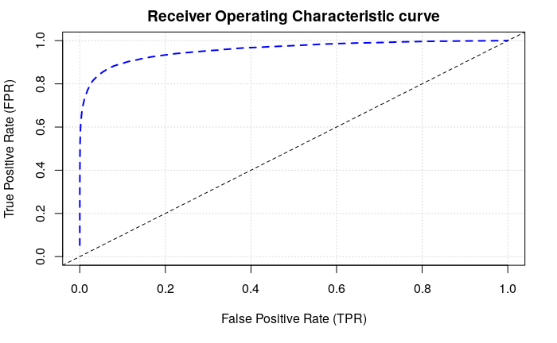

```r
flights.perf <- h2o.performance(model=flights.dl, newdata=flight_test)
plot(flights.perf, type="roc")
```

10. Calculate the prediction accuracy produced by your model using h2o.predict on your model and test data flight_test.

```r
pred <- h2o.predict(flights.dl, newdata=flight_test)
```

```r
flights.perf
```

[output not shown]

11. Calculate the prediction accuracy that would be yielded, for the test data flight_test, by simply using dep_delay (being larger than 30) alone as a predictor.

```r
flights.hex$late_departure <- as.factor(flights.hex$dep_delay > 30)

splits <- h2o.splitFrame(data = flights.hex,
                         ratios = c(0.8),
                         seed = 42)

flight_train <- splits[[1]]
flight_test <- splits[[2]]

flights.dl <- h2o.deeplearning(x=c("late_departure"), y=c("late_arrival"), training_frame=flight_train, seed=42)
flights.perf <- h2o.performance(model=flights.dl, newdata=flight_test)
flights.perf
```

```
H2OBinomialMetrics: deeplearning

MSE:  0.05436655
RMSE:  0.2331664
LogLoss:  0.2143271
Mean Per-Class Error:  0.13123
AUC:  0.86877
AUCPR:  0.7110713
Gini:  0.7375399

Confusion Matrix (vertical: actual; across: predicted) for F1-optimal threshold:
```

|  | 0 | 1 | Error | Rate |
| --- | --- | --- | --- | --- |
| 0 | 55201 | 1550 | 0.027312 | =1550/56751 |
| 1 | 2458 | 7995 | 0.235148 | =2458/10453 |
| Totals | 57659 | 9545 | 0.059639 | =4008/67204 |

```
Maximum Metrics: Maximum metrics at their respective thresholds
```

|  | metric | threshold | value | idx |
| --- | --- | --- | --- | --- |
| 1 | max f1 | 0.852224 | 0.799580 | 0 |
| 2 | max f2 | 0.852224 | 0.778375 | 0 |
| 3 | max f0point5 | 0.852224 | 0.821973 | 0 |
| 4 | max accuracy | 0.852224 | 0.940361 | 0 |
| 5 | max precision | 0.852224 | 0.837611 | 0 |
| 6 | max recall | 0.043935 | 1.000000 | 1 |
| 7 | max specificity | 0.852224 | 0.972688 | 0 |
| 8 | max absolute_mcc | 0.852224 | 0.765722 | 0 |
| 9 | max min_per_class_accuracy | 0.852224 | 0.764852 | 0 |
| 10 | max mean_per_class_accuracy | 0.852224 | 0.868770 | 0 |

[output cut: 8 more lines]

```
Gains/Lift Table: Extract with `h2o.gainsLift(<model>, <data>)` or `h2o.gainsLift(<model>, valid=<T/F>, xval=<T/F>)`
```

```r
h2o.accuracy(flights.perf)
```

|  | threshold | accuracy |
| --- | --- | --- |
| 1 | 0.85222417 | 0.9403607 |
| 2 | 0.04393479 | 0.1555413 |